# 628hw6

Ruohan wang

4/7/2022

```r
#1a
# Required library for ships data set
#install.packages("MASS")
# Required for melt() and cast() function
#install.packages("reshape2")
#install.packages("reshape")
#Loading the libraries
library(MASS)
library(reshape2)
library(reshape)
setwd("~/Downloads")
df <- read.csv("arthritis-data.csv", as.is=TRUE)
#Convert wide-formatted data into long

data <- reshape(df, varying=c("Baseline","Month2", "Month4", "Month6"),
               v.names = "ACS",
                timevar = "Month",
               times =c(0,2,4,6),
              direction = "long")
data = data[!is.na(data$ACS), ]
for(i in 1:nrow(data)){
  if(data$ACS[i] == 1 | data$ACS[i] == 2){
    data$outcome[i] = 1
  }else if(data$ACS[i] == 3){
    data$outcome[i] = 2
  }else if(data$ACS[i] == 4 | data$ACS[i] == 5){
     data$outcome[i] = 3
  }
}
```

```r
#1b
#Delete negative values because these are missing codes and select weeks 2,4,6
#acs <- data[data$ACS %in% c(0,2,4,6),]

#Calculate observed proportions of each category over time by treatment group
#install.packages("plyr")
library(plyr)
```

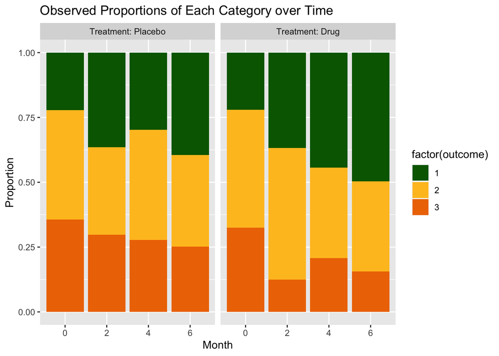

```r
acs_obs <- count(data, c("Treatment","Month","outcome"))
acs_obs$Treatment <- factor(acs_obs$Treatment, levels=c(0,1),labels=c("Placebo","Drug"))
#acs_obs

#Plot observed proportions of each category over time
#install.packages("ggplot2")
#
library(ggplot2)
p1 <- ggplot(data=acs_obs, aes(x=factor(Month), y=freq, fill=factor(outcome)))
p1 + facet_wrap(~Treatment, labeller=label_both) + geom_bar(position="fill", stat="identity") +
  labs(title="Observed Proportions of Each Category over Time", x="Month", y="Proportion") +
  scale_fill_manual(values = c("dark green", "goldenrod1", "darkorange2","red","yellow","blue"))
```

In month0 for the treatment and drug group, the proportion seems very similar, and the proportion of ACS in range 1 is 0.25, proportion of ACS in range 2 is 0.45, proportion of ACS in range 2 is 0.3 approximately.

while in month4 and month6, in the drug groups compared with the placebo groups, the proportion of the ACS in range 1 all increase. which means the drug do have the effect in decrease the level of ACS.

#2a i logit{E(Yij≤ c|bi)}== αc© + β2Trti + β3sqrt(Monthij) + β4Trti x sqrt(Monthij)+ b1i + b3ix sqrt(Monthij)

```r
#2a ii
#install.packages("mixor")
library(mixor)
data$squaremonth = sqrt(data$Month)
data = data[order(data$ID),]
m1 <- mixor(outcome ~ Treatment + squaremonth + Treatment*squaremonth, data=data, id=ID,which.random.slope=2, link="logit", nAGQ=20)
M1<-summary(m1)
```

```
##
## Call:
## mixor(formula = outcome ~ Treatment + squaremonth + Treatment *
##     squaremonth, data = data, id = ID, which.random.slope = 2,
##     nAGQ = 20, link = "logit")
##
## Deviance =         2216.627
## Log-likelihood =  -1108.313
## RIDGEMAX =         0
## AIC =             -1116.313
## SBC =             -1131.168
##
##                         Estimate Std. Error z value   P(>|z|)
## (Intercept)              2.01013    0.24289  8.2761  2.22e-16 ***
## squaremonth             -0.40915    0.10932 -3.7426 0.0001821 ***
## Treatment               -0.17340    0.31849 -0.5445 0.5861276
## Treatment:squaremonth   -0.33087    0.15404 -2.1479 0.0317187 *
## (Intercept) (Intercept)  3.55019    1.07986  3.2876 0.0010103 **
## (Intercept) squaremonth  0.20260    0.32741  0.6188 0.5360541
## squaremonth squaremonth  0.29817    0.19387  1.5380 0.1240464
## Threshold2               3.06520    0.17602 17.4141 < 2.2e-16 ***
## ---
## Signif. codes:  0 '***' 0.001 '**' 0.01 '*' 0.05 '.' 0.1 ' ' 1
```

```r
M1
```

```
##                           Estimate Std. Error    z value      P(>|z|)
## (Intercept)              2.0101333  0.2428854  8.2760581 2.220446e-16
## squaremonth             -0.4091542  0.1093221 -3.7426475 1.820916e-04
## Treatment               -0.1734048  0.3184917 -0.5444562 5.861276e-01
## Treatment:squaremonth   -0.3308692  0.1540404 -2.1479377 3.171871e-02
## (Intercept) (Intercept)  3.5501901  1.0798585  3.2876438 1.010296e-03
## (Intercept) squaremonth  0.2025976  0.3274088  0.6187909 5.360541e-01
## squaremonth squaremonth  0.2981674  0.1938658  1.5380090 1.240464e-01
## Threshold2               3.0652027  0.1760188 17.4140645 0.000000e+00
```

```r
m2 <- mixor(outcome ~ Treatment + squaremonth + Treatment*squaremonth, data=data, id=ID,which.random.slope=2, link="logit", nAGQ=10)
M2<-summary(m2)
```

```
##
## Call:
## mixor(formula = outcome ~ Treatment + squaremonth + Treatment *
##     squaremonth, data = data, id = ID, which.random.slope = 2,
##     nAGQ = 10, link = "logit")
##
## Deviance =         2216.627
## Log-likelihood =  -1108.313
## RIDGEMAX =         0
## AIC =             -1116.313
## SBC =             -1131.168
##
##                         Estimate Std. Error z value   P(>|z|)
## (Intercept)              2.01015    0.24289  8.2761  2.22e-16 ***
## squaremonth             -0.40916    0.10932 -3.7427 0.0001821 ***
## Treatment               -0.17341    0.31850 -0.5445 0.5861202
## Treatment:squaremonth   -0.33087    0.15404 -2.1479 0.0317192 *
## (Intercept) (Intercept)  3.55032    1.07987  3.2877 0.0010100 **
## (Intercept) squaremonth  0.20256    0.32742  0.6187 0.5361407
## squaremonth squaremonth  0.29818    0.19386  1.5381 0.1240229
## Threshold2               3.06522    0.17602 17.4141 < 2.2e-16 ***
## ---
## Signif. codes:  0 '***' 0.001 '**' 0.01 '*' 0.05 '.' 0.1 ' ' 1
```

```r
M2
```

```
##                           Estimate Std. Error    z value      P(>|z|)
## (Intercept)              2.0101496  0.2428864  8.2760881 2.220446e-16
## squaremonth             -0.4091605  0.1093229 -3.7426777 1.820697e-04
## Treatment               -0.1734113  0.3184974 -0.5444670 5.861202e-01
## Treatment:squaremonth   -0.3308710  0.1540417 -2.1479319 3.171917e-02
## (Intercept) (Intercept)  3.5503158  1.0798733  3.2877150 1.010040e-03
## (Intercept) squaremonth  0.2025630  0.3274225  0.6186594 5.361407e-01
## squaremonth squaremonth  0.2981807  0.1938624  1.5381051 1.240229e-01
## Threshold2               3.0652191  0.1760191 17.4141322 0.000000e+00
```

```r
#change the nAGQ threshold they have the same performance of the aic and other performance, so they should be the same.
```

```r
#2a iii
m1.1 <- mixor(outcome ~ Treatment + squaremonth + Treatment*squaremonth, data=data, id=ID, link="logit", nAGQ=20)
M1.1<-summary(m1.1)
```

```
##
## Call:
## mixor(formula = outcome ~ Treatment + squaremonth + Treatment *
##     squaremonth, data = data, id = ID, nAGQ = 20, link = "logit")
##
## Deviance =         2227.309
## Log-likelihood =  -1113.654
## RIDGEMAX =         0.3
## AIC =             -1119.654
## SBC =             -1130.796
##
##                        Estimate Std. Error z value   P(>|z|)
## (Intercept)            1.940530   0.252031  7.6996 1.354e-14 ***
## Treatment             -0.192955   0.343643 -0.5615   0.57446
## squaremonth           -0.392600   0.091544 -4.2886 1.798e-05 ***
## Treatment:squaremonth -0.289183   0.128638 -2.2480   0.02457 *
## Random.(Intercept)     4.157944   0.609870  6.8178 9.247e-12 ***
## Threshold2             2.925249   0.133026 21.9900 < 2.2e-16 ***
## ---
## Signif. codes:  0 '***' 0.001 '**' 0.01 '*' 0.05 '.' 0.1 ' ' 1
```

```r
M1.1
```

```
##                         Estimate Std. Error    z value      P(>|z|)
## (Intercept)            1.9405300 0.25203118  7.6995635 1.354472e-14
## Treatment             -0.1929552 0.34364278 -0.5614994 5.744572e-01
## squaremonth           -0.3926000 0.09154433 -4.2886322 1.797768e-05
## Treatment:squaremonth -0.2891830 0.12863838 -2.2480306 2.457424e-02
## Random.(Intercept)     4.1579435 0.60986957  6.8177586 9.247270e-12
## Threshold2             2.9252489 0.13302632 21.9900014 0.000000e+00
```

```r
test.statitistic <- -2*(m1.1$RLOGL-m1$RLOGL)
test.statitistic
```

```
## [1] 10.68215
```

```r
p.value <- 0.5*(1-pchisq(test.statitistic,1)) + 0.5*(1-pchisq(test.statitistic,2))
p.value
```

```
## [1] 0.002936225
```

We should use the chi-square test, with the LRT of df1=1 df2=2 to compare m1 and m1.1 since the p value is 0.002936225 which is significant so we need to reject H0, which means we should keep random slope.

Interpret random effect: for every squaremonth unit change in Xijk , the log-odds of a cumulative response patients’ difference change probability will change by β for an individual with propensity to respond ‘higher or lower’ (depending on whether lower or higher values are modeled) equal to bi .

```r
#2 iv
m1 <- mixor(outcome ~ Treatment + squaremonth + Treatment*squaremonth, data=data, id=ID,which.random.slope=2, link="logit", nAGQ=20)
summary(m1)
```

```
##
## Call:
## mixor(formula = outcome ~ Treatment + squaremonth + Treatment *
##     squaremonth, data = data, id = ID, which.random.slope = 2,
##     nAGQ = 20, link = "logit")
##
## Deviance =         2216.627
## Log-likelihood =  -1108.313
## RIDGEMAX =         0
## AIC =             -1116.313
## SBC =             -1131.168
##
##                         Estimate Std. Error z value   P(>|z|)
## (Intercept)              2.01013    0.24289  8.2761  2.22e-16 ***
## squaremonth             -0.40915    0.10932 -3.7426 0.0001821 ***
## Treatment               -0.17340    0.31849 -0.5445 0.5861276
## Treatment:squaremonth   -0.33087    0.15404 -2.1479 0.0317187 *
## (Intercept) (Intercept)  3.55019    1.07986  3.2876 0.0010103 **
## (Intercept) squaremonth  0.20260    0.32741  0.6188 0.5360541
## squaremonth squaremonth  0.29817    0.19387  1.5380 0.1240464
## Threshold2               3.06520    0.17602 17.4141 < 2.2e-16 ***
## ---
## Signif. codes:  0 '***' 0.001 '**' 0.01 '*' 0.05 '.' 0.1 ' ' 1
```

since we choose the random slope and random intercept model, which is m1. Use Wald or LRT test, from above result, we can know that the beta4’s Treatment:squaremonth p value 0.0317187, which is smaller than 0.05, so reject null hypothesis. H0 is beta4 = 0, Ha. is beta not =0 . Therefor there is a significant effect of intervention group on the change in subject-specific odds of a more favorable response over the duration of the study.

```r
#2 vi
##########################################
#Plot (C-1) logits by treatment group    #
##########################################
#Output common intercepts for each logit:
alpha1_C<- -M1[1,1]
alpha1_C
```

```
## [1] -2.010133
```

```r
alpha2_C<-M1[8,1] - M1[1,1]
alpha2_C
```

```
## [1] 1.055069
```

```r
#Output estimates of Betas for covariates:
Beta2<-M1[2,1]
Beta2
```

```
## [1] -0.4091542
```

```r
Beta3<-M1[3,1]
Beta3
```

```
## [1] -0.1734048
```

```r
Beta4<-M1[4,1]
Beta4
```

```
## [1] -0.3308692
```

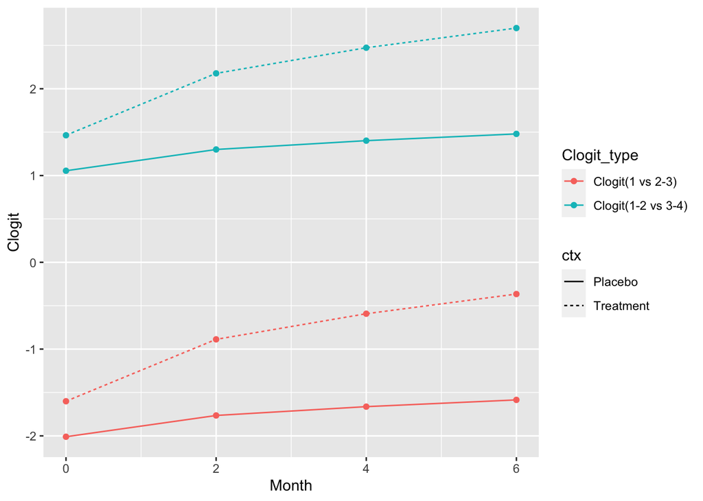

```r
time<-c(0,2,4,6)

est.cum.logit<-data.frame(Month=rep(time,times=2), SW=rep(sqrt(time),times=2), treatment=c(rep(0,times=4),rep(1,times=4)),
                                alpha12_C=c(rep(alpha1_C,times=8),rep(alpha2_C,times=8)),
                Clogit_type=c(rep("Clogit(1 vs 2-3)",times=8),rep("Clogit(1-2 vs 3-4)",times=8)))

est.cum.logit$TSW<-est.cum.logit$SW*est.cum.logit$treatment
est.cum.logit$Clogit<-est.cum.logit$alpha12_C-(Beta2*est.cum.logit$treatment+Beta3*est.cum.logit$SW+Beta4*est.cum.logit$TSW)
est.cum.logit$ctx <- factor(est.cum.logit$treatment, levels=c(0,1), labels=c("Placebo","Treatment"))
#est.cum.logit

p2 <- ggplot(est.cum.logit, aes(x = Month, y = Clogit, group = interaction(ctx, Clogit_type)))
p2 + geom_line(aes(color = Clogit_type,linetype =ctx )) +
  geom_point((aes(color = Clogit_type)))
```

```r
# +labs(title = "Estimated cumulative logits for typical patient by treatement by Month", y = "Estimated Cumulative Logit", color="Cumulative Log-Odds", linetype ="Treatment Group")
```

According to the slides, “Proportionality Assumption: if a unit increase in a covariate doubles the odds of being in Yi=1 vs. Yi>1, it also doubles the odds of being in Yi≤2 vs. Yi>2, etc” And we can tell from the plot: that The slope of change in the cumulative log-odds for and the log-odds are increasing proportionally across different cumulative logits, and the ratios remain constant, which obeys the Proportionality Assumption.

```r
#2 vii
eta1<-est.cum.logit[1:8,]
eta2<-est.cum.logit[9:16,]
eta<-eta1[,c("Month","SW","treatment","alpha12_C","TSW","Clogit","ctx")]
names(eta)<-c("Month","SW","treatment","alpha12_C","TSW","eta1","ctx")
eta$eta2<-eta2$Clogit
#eta

eta$mu_1<-1/(1+exp(-eta$eta1))
eta$mu_2<-1/(1+exp(-eta$eta2))-1/(1+exp(-eta$eta1))
eta$mu_3<-1-1/(1+exp(-eta$eta2))
#eta

est.mu.data<-data.frame(Month=rep(eta$Month,times=3),
                     ctx=rep(eta$ctx,times=3),
                     mu=c(eta$mu_1,eta$mu_2,eta$mu_3),
                     mu.label=c(rep("Pr(Yij=1)",times=8),
                              rep("Pr(Yij=2)",times=8), rep("Pr(Yij=3)",times=8)))
for (i in 1:nrow(est.mu.data)) {
  est.mu.data$label[i]<-paste(as.character(est.mu.data$ctx[i]),as.character(est.mu.data$mu.label[i]))
}
est.mu.data
```

```
##    Month       ctx         mu  mu.label               label
## 1      0   Placebo 0.11814309 Pr(Yij=1)   Placebo Pr(Yij=1)
## 2      2   Placebo 0.14617747 Pr(Yij=1)   Placebo Pr(Yij=1)
## 3      4   Placebo 0.15931633 Pr(Yij=1)   Placebo Pr(Yij=1)
## 4      6   Placebo 0.17003488 Pr(Yij=1)   Placebo Pr(Yij=1)
## 5      0 Treatment 0.16784481 Pr(Yij=1) Treatment Pr(Yij=1)
## 6      2 Treatment 0.29155827 Pr(Yij=1) Treatment Pr(Yij=1)
## 7      4 Treatment 0.35607726 Pr(Yij=1) Treatment Pr(Yij=1)
## 8      6 Treatment 0.40956474 Pr(Yij=1) Treatment Pr(Yij=1)
## 9      0   Placebo 0.62360407 Pr(Yij=2)   Placebo Pr(Yij=2)
## 10     2   Placebo 0.63970812 Pr(Yij=2)   Placebo Pr(Yij=2)
## 11     4   Placebo 0.64316555 Pr(Yij=2)   Placebo Pr(Yij=2)
## 12     6   Placebo 0.64451090 Pr(Yij=2)   Placebo Pr(Yij=2)
## 13     0 Treatment 0.64433299 Pr(Yij=2) Treatment Pr(Yij=2)
## 14     2 Treatment 0.60664100 Pr(Yij=2) Treatment Pr(Yij=2)
## 15     4 Treatment 0.56613357 Pr(Yij=2) Treatment Pr(Yij=2)
## 16     6 Treatment 0.52742871 Pr(Yij=2) Treatment Pr(Yij=2)
## 17     0   Placebo 0.25825284 Pr(Yij=3)   Placebo Pr(Yij=3)
## 18     2   Placebo 0.21411441 Pr(Yij=3)   Placebo Pr(Yij=3)
## 19     4   Placebo 0.19751812 Pr(Yij=3)   Placebo Pr(Yij=3)
## 20     6   Placebo 0.18545422 Pr(Yij=3)   Placebo Pr(Yij=3)
## 21     0 Treatment 0.18782219 Pr(Yij=3) Treatment Pr(Yij=3)
## 22     2 Treatment 0.10180072 Pr(Yij=3) Treatment Pr(Yij=3)
## 23     4 Treatment 0.07778917 Pr(Yij=3) Treatment Pr(Yij=3)
## 24     6 Treatment 0.06300655 Pr(Yij=3) Treatment Pr(Yij=3)
```

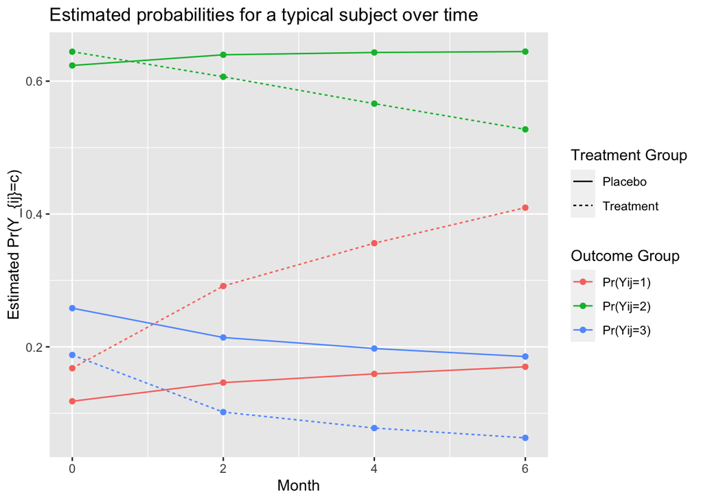

```r
#All Logits in One Plot
p4 <- ggplot(est.mu.data, aes(x = Month, y = mu, group = interaction(ctx, mu.label)))
p4 + geom_line(aes(color = mu.label,linetype =ctx)) +
  geom_point((aes(color = mu.label)))+
labs(title = "Estimated probabilities for a typical subject over time",color = "Outcome Group", y = "Estimated Pr(Y_{ij}=c)",linetype ="Treatment Group")
```

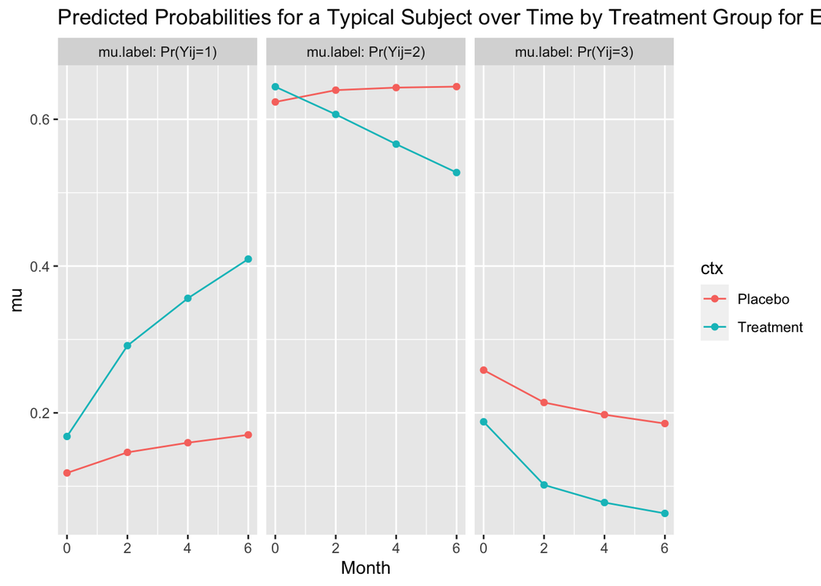

```r
#Stratified by Logit
#Plot predicted probabilities over time by treatment group for each category (IDENTICAL to p6 below!)
p5 <- ggplot(est.mu.data, aes(x=Month, y=mu, group=ctx))
p5 + facet_wrap(~mu.label, labeller=label_both) +
  geom_line(aes(color=ctx)) + geom_point(aes(color=ctx)) +
  labs(title="Predicted Probabilities for a Typical Subject over Time by Treatment Group for Each Outcome Category")
```

The plots draw the estimate probabilities for a ‘typical subject’ of each of the 3 categories in the outcome over the study period by the treatment groups (months 0, 2,4,6). But when mu =1, the placebo has a lower level of the probability, while in the mu =2,4, the placebo has a higher level of the probability than the treatment.

```r
#2 viii
month <- c(0, 2, 4, 6)
sqrtmonth <- sqrt(c(0,2,4,6))
or <- exp(Beta4*sqrtmonth)
or
```

```
## [1] 1.0000000 0.6263038 0.5159536 0.4446531
```

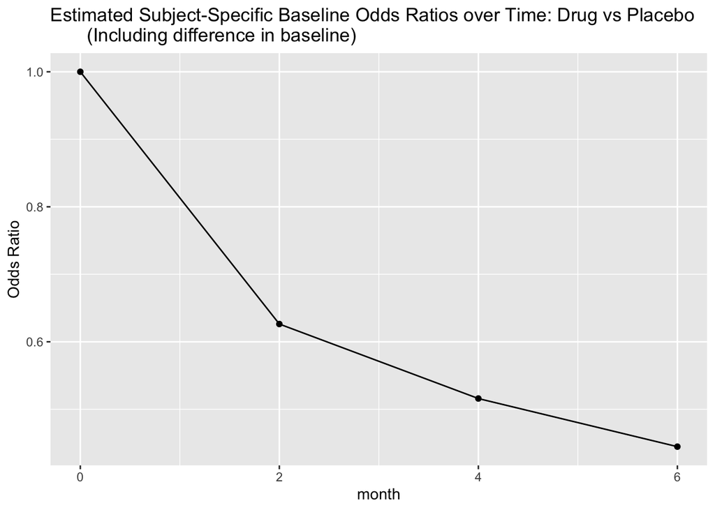

```r
#Get odds ratios
ds = data.frame(month, or)

#Plot estimated subject-specific baseline odds ratios over time (Drug vs Placebo)
p2 <- ggplot(ds, aes(x=month, y=or))
p2 + geom_line() + geom_point() +
  labs(title="Estimated Subject-Specific Baseline Odds Ratios over Time: Drug vs Placebo
       (Including difference in baseline)", y="Odds Ratio")
```

2. 9. From the textbook, the estimates of the trt:sqrtmonth is 0.4005. which are different from the m1, Trt:squaremonth -0.33087. The reason why they are different: because the book use the different calculatuion method, with different principle, so they are different.

#3a i

Let Yij ={1,2,3…n} for the ith patient self-reporting scale value in the jth occasion (j=0 [baseline],2 [2mo], 4 [4 mo], 6 [6 mo]).

logit{E(Yij=c|bi(c))} = log{ Pr (Yij= c|bi(c)) / Pr (Yij =C|bi(c)) } =  
= β1(c) + β2(c)Trti + β3(c)sqrt(Timeij) + β4(c)Trti x sqrt(Timeij)+ b1i(c)

```r
#3a ii
#install.packages("vcrpart")
library(vcrpart)
data$ID = as.factor(data$ID)
data$outcome= as.factor(data$outcome)
m3.1 <- olmm(outcome ~ Treatment + squaremonth + Treatment*squaremonth + re(1|ID), data=data, family=baseline())
summary(m3.1)
```

```
## Linear Mixed Model fit by Marginal Maximum
## Likelihood with Gauss-Hermite Quadrature
##
##  Family: baseline logit
## Formula: outcome ~ Treatment + squaremonth + Treatment * squaremonth +
##     re(1 | ID)
##    Data: data
##
## Goodness of fit:
##       AIC      BIC    logLik
##  2240.519 2296.454 -1109.259
##
## Random effects:
## Subject: ID
##                 Variance   StdDev     Corr
## 1|3:(Intercept) 11.5487403  3.3983438 1|3:(Intercept)
## 2|3:(Intercept)  2.3239756  1.5244591  0.9481255
## Number of obs: 1194, subjects: 303
##
## Category-specific fixed effects:
##                           Estimate Std. Error z value
## 1|3:(Intercept)           -1.06262    0.42922 -2.4757
## 1|3:Treatment              0.27505    0.57137  0.4814
## 1|3:squaremonth            0.66196    0.16163  4.0955
## 1|3:Treatment:squaremonth  0.54073    0.22620  2.3905
## 2|3:(Intercept)            0.60832    0.25207  2.4132
## 2|3:Treatment              0.41657    0.34823  1.1962
## 2|3:squaremonth            0.21839    0.11731  1.8616
## 2|3:Treatment:squaremonth  0.17989    0.17359  1.0363
```

For the random effect,for every one unit change in Xijk , the log-odds of a chosen response category relative to the baseline category will change by β(c) for an individual with propensity to respond ‘higher orlower’ relative to the baseline category (depending on whether lower or higher values are modeled) equal to bi(c).

```r
#3a iii
m3.1.1<- olmm(outcome ~ Treatment + squaremonth + re(1|ID), data=data, family=baseline())
anova(m3.1,m3.1.1)
```

```
## Data: data
## Models:
## m3.1.1: outcome ~ Treatment + squaremonth + re(1 | ID)
## m3.1: outcome ~ Treatment + squaremonth + Treatment * squaremonth +
## m3.1:     re(1 | ID)
##        Df    AIC    BIC  logLik  Chisq Chi Df Pr(>Chisq)
## m3.1.1  9 2241.8 2287.6 -1111.9
## m3.1   11 2240.5 2296.4 -1109.3 5.3292      2    0.06963 .
## ---
## Signif. codes:  0 '***' 0.001 '**' 0.01 '*' 0.05 '.' 0.1 ' ' 1
```

H0; for beta4 Treatment:squaremonth, beta41 = beta42 =0 Ha: at least for beta4 Treatment:squaremonth, beta41 = beta42 !=0

#3.a. iv interpret the estimates for the intercepts when the response is nominal (the current model): for every one unit change in Xijk , the log-expected-count (or the log-expected-rate) will change by β for a ‘typical subject’, i.e., bi=0 for mean and median.

while in 2v is alpha1c: 1st cumulative logit{Pr(Yij<1)} in Placebo group’s ‘typical’ patient in Month=0.

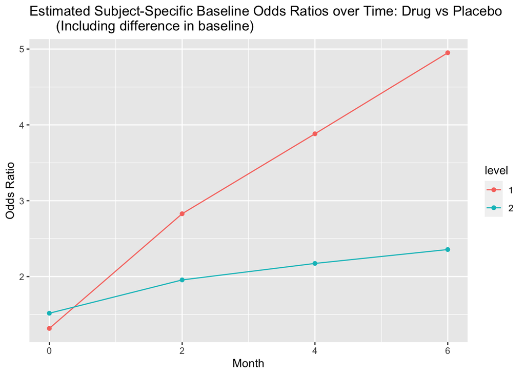

```r
## 3v
#Delete duplicates
m1.pred.eta <- predict(m3.1, type="link", ranef=FALSE)
m1.pred.eta <- data.frame(unique(cbind(tx=data$Treatment, Month=data$Month, m1.pred.eta)))
#Reshape m1.pred.eta from wide to long
m1.pred.eta <- reshape(m1.pred.eta, varying=list(3:4), direction="long")


### Include the treatment differene in baseline
#Calculate subject-specific ratios of increased odds of a favorable outcome across time
#in subjects randomized to anti-psychotic medication relative to subjects randomized to placebo
or1 <- m1.pred.eta[m1.pred.eta$tx==1,-5]
or <- cbind(or1, Eta0=m1.pred.eta[m1.pred.eta$tx==0,4])
or$logor <- or$Eta1 - or$Eta0
#Get odds ratios
or$or <- exp(or$logor)
#Create a factor variable
or$level <- factor(or$time)

#Plot estimated subject-specific baseline odds ratios over time (Drug vs Placebo)
p2 <- ggplot(or, aes(x=Month, y=or, group=level))
p2 + geom_line(aes(color=level)) + geom_point(aes(color=level)) +
  labs(title="Estimated Subject-Specific Baseline Odds Ratios over Time: Drug vs Placebo
       (Including difference in baseline)", y="Odds Ratio")
```

Interpret the estimated odds ratios at 4 months of follow up for each specific equation:

Estimated ORt=4 = exp(β41*sqrt(4))=exp(0.54073*2)=2.94898

At 4 months, a patient assigned to treatment is approximately 2.94898 times more likely to feel “Very Good” vs. “Very Poor” when compared to a similar patient treated with placebo.

Estimated ORt=4 = exp(β42*sqrt(4))=exp(0.17989*2)=1.43301

At 4 months, a patient assigned to treatment is approximately 1.43301 times more likely to feel “Fair” vs. “Very Poor” when compared to a similar patient treated with placebo.

#3a vi

```r
newdata = data.frame(squaremonth=sqrt(6),Treatment=1)
predict(m3.1, newdata, type="response")
```

```
##           1         2         3
## 1 0.4949038 0.3583302 0.1460827
```

The probabilities are above.